# Empire State Poll Analysis

### Plausible value in PIAAC

PIAAC cannot provide individual-level results, because each adult answers only a small number of assessment questions. PIAAC provides reliable estimates of proficiency only at the national level, or at the level of large subgroups (e.g., females, employed, or college educated).

Plausible Values (PVs) allows PIAAC dataset information to be saved at the case level to estimate proficiency at the national or subgroup level. Each case’s PVs reflect not only that individual’s performance on the small number of items s/he answered, but also the performance of similar respondents on the rest of the PIAAC assessment.

Each individual case in the PIAAC dataset has a randomly chosen set of ten plausible values (PVs). All ten PVs must be used together to estimate proficiency, or else one understates the variability in the predicted outcomes. The randomly chosen set of PVs best represents the score distribution for a subgroup of adults.

reference:  
https://cran.r-project.org/web/packages/intsvy/intsvy.pdf  
https://nces.ed.gov/training/datauser/PIAAC_04/assets/PIAAC_04.pdf  
https://www.oecd.org/skills/piaac/piactools_16oct_for_web.pdf

*Question:*

Should we use either PV1 or the combination from PV1 to PV10?

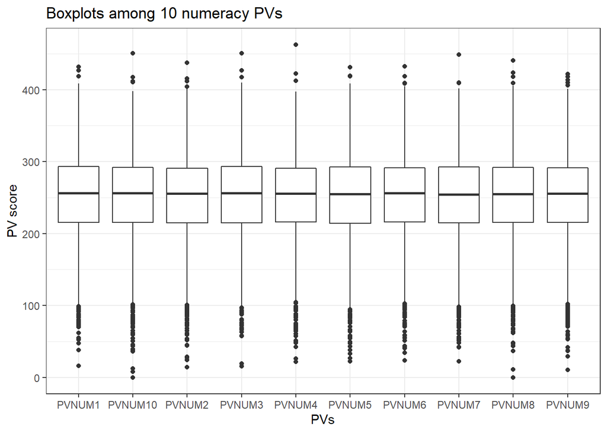

```r
# raw_PIAAC <- read_spss("../Data/prgusap1_puf.sav")
raw_PIAAC <- haven::read_spss("../data/prgusap1_puf.sav")
num_pv <- paste0("PVNUM", 1:10)
# paste(num_pv, collapse = " + ")

pv <- raw_PIAAC[, num_pv] %>%
  gather(key = "PVs", value = "value")
#table1(~ PVNUM1 + PVNUM2 + PVNUM3 + PVNUM4 + PVNUM5 + PVNUM6 +
#         PVNUM7 + PVNUM8 + PVNUM9 + PVNUM10, data = pv)

ggplot(data = pv) +
  geom_boxplot(aes(x = PVs, y = value)) +
  scale_x_discrete() +
  ggtitle("Boxplots among 10 numeracy PVs") +
  ylab("PV score") +
  theme_bw()
```

```r
summary(aov(value ~ PVs, data = pv))
```

```
##                Df    Sum Sq Mean Sq F value Pr(>F)
## PVs             9      3261     362    0.11      1
## Residuals   34780 116309634    3344
## 1810 observations deleted due to missingness
```

ANOVA test shows that there is no significant difference between these 10 PVs.

### Correlation between heath status and numeracy score

The numeracy proficiency score are calculated with the implemented function “piaac.mean.pv” in the package “intsvy”. This function uses ten plausible values to calculate the mean achievement score and its standard error.

The t-test statistics are calculated using the online t-test calculator:  
https://select-statistics.co.uk/calculators/two-sample-t-test-calculator/

Health Staus 1 : Not Poor VS. Poor  
Health status 2: Good VS. Not Good

```r
PIAAC.pv <- cbind(PIAAC[, c("educ", "income.cat", "race",
                            "health_status_1", "health_status_2")],
                  raw_PIAAC %>% filter(!is.na(I_Q08)))

pv1 <- piaac.mean.pv(pvlabel = "NUM", by = "health_status_1", data = PIAAC.pv)[-3, 1:4]
pv1$p_val <- c("<0.001", "")
pv1 %>%
  kable()%>%
  kable_styling(full_width = F)
```

| health_status_1 | Freq | Mean | s.e. | p_val |
| --- | --- | --- | --- | --- |
| Not Poor | 3354 | 254 | 1.39 | <0.001 |
| Poor | 121 | 227 | 6.44 |  |

```r
pv2 <- piaac.mean.pv(pvlabel = "NUM", by = "health_status_2", data = PIAAC.pv) [-3, 1:4]
pv2$p_val <- c("<0.001", "")
pv2 %>%
  kable()%>%
  kable_styling(full_width = F)
```

| health_status_2 | Freq | Mean | s.e. | p_val |
| --- | --- | --- | --- | --- |
| Good | 2851 | 258 | 1.50 | <0.001 |
| Not Good | 624 | 230 | 2.49 |  |

The two-sample t-test results show that numeracy score is positively associated with people’s health status.

## RVq2

How often during the last 12 months did you, as a patient, visit a care provider for a health problem or preventative care (like checkups)? This includes physical, mental, or dental health provided in any type of healthcare facilities.

- 1. Never
- 2. 1-2 times
- 3. Once every few months
- 4. Once a month
- 5. Twice a month
- 6. Once a week
- 7. 2-3 times a week

### Distribution (barplot)

```r
as.data.frame(t(quantile(ESP$RVq2))) %>%
  kable() %>%
  kable_styling(full_width = F)
```

| 0% | 25% | 50% | 75% | 100% |
| --- | --- | --- | --- | --- |
| 1 | 2 | 3 | 3 | 7 |

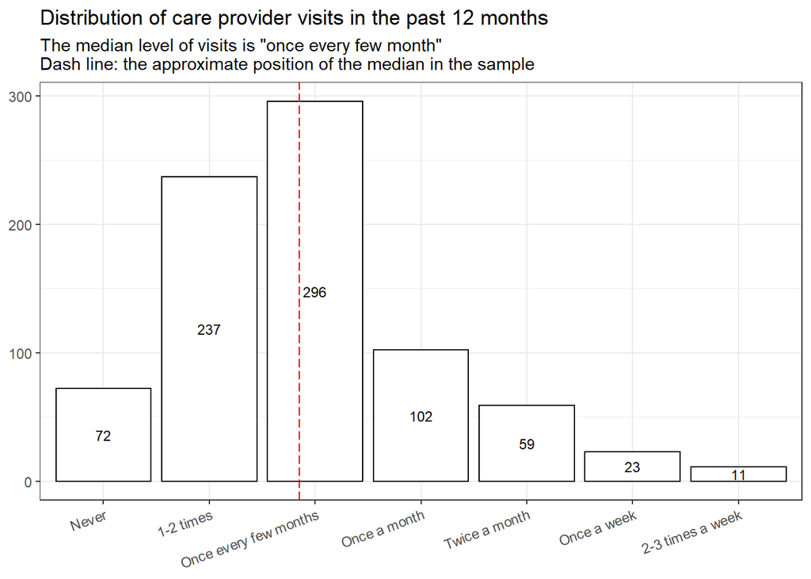

```r
# table(ESP$visits_response_1y, useNA = "ifany")
# median(ESP$RVq2)
ESP %>%
  ggplot() +
  # draw the basic bar plot
  geom_bar(aes(x = visits_response_1y), stat = "count", fill = "white", color = "black") +
  # add the count label to each bar
  geom_text(stat = "count", aes(x = visits_response_1y, label = ..count..), position = position_stack(vjust = 0.5), size = 3.2) +
  # add a vertical dash line showing the position of median visit level
  # the median level is 3: once every few month
  # the first half of the sample is made up of:
    # 72 never + 237 1-2 times + 91 once every few month
    # 91 is about 1/3 of the whole "once every few month" group
  # thus the position of the dash line is at about 1/3 of the bar of "once every few month
  geom_vline(xintercept = 2.85,linetype = "longdash", color = "red", ) +
  theme_bw() +
  # rotate the x-axis labels to avoid overlap
  theme(axis.text.x = element_text(angle = 20, hjust = 1)) +
  labs(x = NULL, y = NULL,
       title = "Distribution of care provider visits in the past 12 months",
       subtitle = 'The median level of visits is "once every few month"\nDash line: the approximate position of the median in the sample')
```

### RVq2 and JAq4

#### Distribution

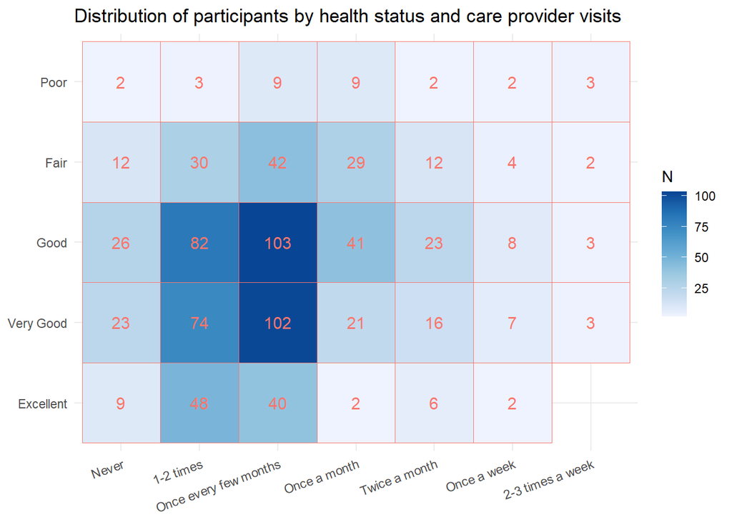

```r
ESP %>%
  group_by(visits_response_1y, health_status) %>%
  # summarise the number in each combination of care provider visits and health status
  summarise(N = n()) %>%
  # fill each tile by N
  # no matter what color I set here, the output plot always shows the same color, which is weird
  ggplot(aes(x=visits_response_1y, y=health_status, fill=N, color = "")) +
  # plot heatmap
  geom_tile() +
  # add the count label to each tile
  geom_text(aes(label = N), size = 4) +
  # change direction to reverse the order of the color corresponding to the count levels
  scale_fill_distiller(palette = "Blues", direction = "horizontal") +
  theme_minimal() +
  # rotate the x-axis labels to avoid overlap
  theme(axis.text.x = element_text(angle = 20, hjust = 1)) +
  labs(x = NULL, y = NULL, title = "Distribution of participants by health status and care provider visits") +
  # omit the legend of color
  guides(color = F)
```

#### Correlation: Cramer’s V

Since both of RVq2 (care provider visits) and JAq4 (health_status) are categorical variables, traditional test such as chi-square test and fisher’s test is not applicable. We calculate Cramer’s V based on chi-square statistic here to evaluate the correlation between the two outcome of interest. **The smaller V, the lower the correlation.**

[Overview of correlation measures between categorical and continuous variables](https://medium.com/@outside2SDs/an-overview-of-correlation-measures-between-categorical-and-continuous-variables-4c7f85610365)

[Wikipedia of Cramer’s V](https://en.wikipedia.org/wiki/Cram%C3%A9r%27s_V)

[Implementation in R](https://datascience.stackexchange.com/questions/893/how-to-get-correlation-between-two-categorical-variable-and-a-categorical-variab)

```r
# v.cclt (Cramer's V Calculator) is a function calculating Cramer's V
v.cclt <- function(tbl) {
  chi2 <- chisq.test(tbl, correct = F)
  v <- sqrt(chi2$statistic / sum(tbl))
  names(v) <- NULL
  return(v)
}

tbl <- table(ESP$visits_response_1y, ESP$health_status)
v.cclt(tbl)
```

```
## [1] 0.293
```

As V = 0.293, there is no strong correlation between RVq2 (care provider visits) and JAq4 (health_status).

### RVq2 and numeracy score

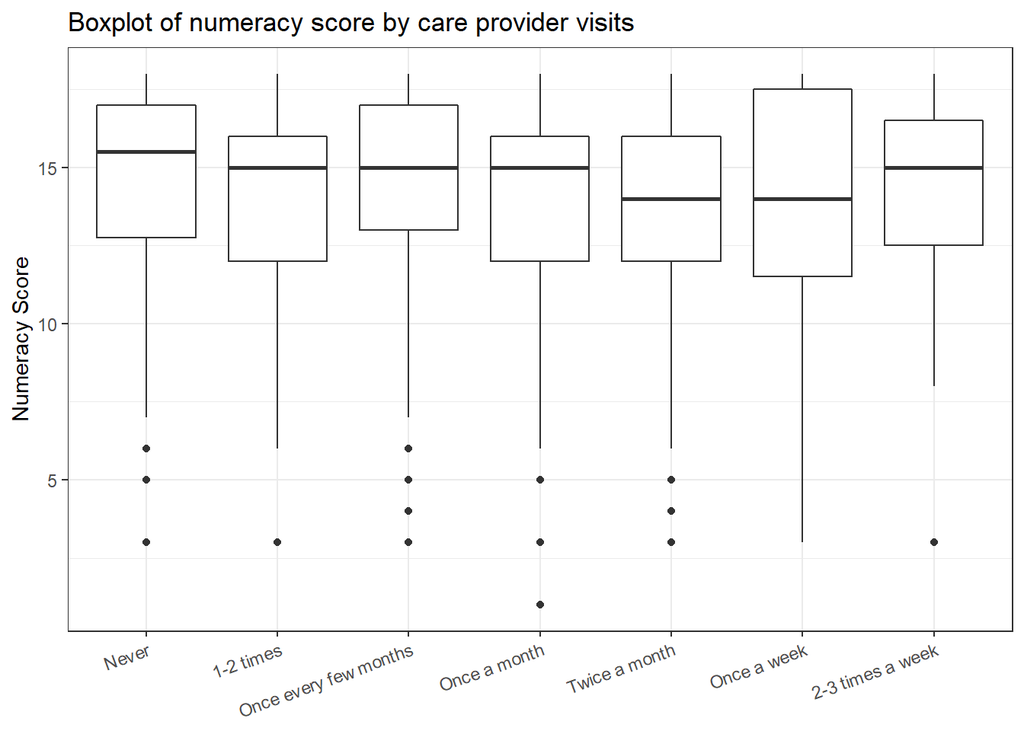

```r
ESP %>%
  ggplot() +
  geom_boxplot(aes(x=visits_response_1y, y=numeracy)) +
  theme_bw() +
  # rotate the x-axis labels to avoid overlap
  theme(axis.text.x = element_text(angle = 20, hjust = 1)) +
  labs(x = NULL, y = "Numeracy Score", title = "Boxplot of numeracy score by care provider visits")
```

```r
# performe one-way ANOVA test
summary(aov(numeracy~visits_response_1y, data = ESP))
```

```
##                     Df Sum Sq Mean Sq F value Pr(>F)
## visits_response_1y   6     83    13.8    1.21    0.3
## Residuals          793   9003    11.3
```

There is no significant difference across the RVq2 groups regarding numeracy score.

### RVq2 and covariates

#### Correlation: Cramer’s V

```r
covariates <- c("gender", "age.cat", "educ", "income.cat", "race", "hisp")
v.values <- sapply(ESP[covariates],function(x) v.cclt(table(ESP$visits_response_1y,x)))
v.values <- t(v.values) %>% as.data.frame()
rownames(v.values) <- "V"
kable(v.values) %>%
  kable_styling(full_width = F)
```

|  | gender | age.cat | educ | income.cat | race | hisp |
| --- | --- | --- | --- | --- | --- | --- |
| V | 0.202 | 0.223 | 0.198 | 0.216 | 0.233 | 0.17 |

### Regression

#### Logistic Regression: treat RVq2 as categorical data

Not often (#visits <=2) VS. Often (#visits >= 3)

- Predictor: numeracy score
- Covariates: education, ethincity, income, race
- Interaction term: education & numeracy score

| Outcome | Visit to doctors (Not Often VS. Often) |
| --- | --- |
| significant predictor |  |
| significant covariates | education, ethnicity, race |
| AUC | 0.6348 |
| Power (for efucational status) | 87.80% (85.61, 89.76) |

#### Poisson Regression: treat RVq2 as count data

1. In the univariate model using the the number of visitiing healthy care provider, below are siginificant covariates. Noticable that numeracy is not a significant predictor in univariate model.
- Health status 2: Good vs. Not Good
  - Age categories
  - Income
  - Education
2. Model Selection: Backward

Outcome: number of visiting healthy care provider in the last year

Predictors:  
- Health status 1: Poor vs. Not Poor (p-value=0.009)

## Appendix

### ESP: Not Poor vs Poor

- Outcome: binary health status
- Predictor: numeracy score
- Covariates: education, ethincity, income, race
- Interaction term: education & numeracy score

```r
ESP$health_status_1 <- relevel(ESP$health_status_1, ref = "Not Poor")
full1 <- glm(health_status_1 ~ numeracy + educ + hisp + race +
               income.cat + educ:numeracy, data = ESP,
             family = "binomial")
final1 <- step(full1, direction = "both", trace = 0)
multi_summary1 <- exp(cbind(coef(final1), confint(final1))[-1, ]) %>% as.data.frame()
colnames(multi_summary1)[1] <- "OR"
multi_summary1$sig <- ifelse(summary(final1)$coefficients[-1, 4] < 0.05, "*", "")

# power calculation
powerSim(final1, nsim = 100,  progress = FALSE)
```

```
## Power for predictor 'numeracy', (95% confidence interval):
##       57.00% (46.71, 66.86)
##
## Test: z-test
##
## Based on 100 simulations, (34 warnings, 0 errors)
## alpha = 0.05, nrow = 800
##
## Time elapsed: 0 h 0 m 3 s
##
## nb: result might be an observed power calculation
```

```r
kable(multi_summary1) %>%
  kable_styling()
```

OR

2.5 %

97.5 %

sig

numeracy

0.901

0.816

9.98e-01

educSome college or associate’s degree

0.782

0.329

1.83e+00

educBachelor’s degree or higher

0.188

0.041

6.35e-01

educRefused

28.077

0.623

2.07e+03

hispNon-hispanic

1.956

0.715

6.90e+00

hispRefused

44.643

1.372

1.59e+03

income.cat$50k-$100k

0.610

0.237

1.46e+00

income.cat$100k-$150k

0.233

0.013

1.23e+00

income.cat$150k+

0.000

0.000

1.95e+12

income.catNo Data

0.294

0.011

2.00e+00

Step-wise multivariate regression model was conducted. The final model has four variables (educ, hisp, income and numeracy). The AUC is 0.8196 with ROC curve shown below.

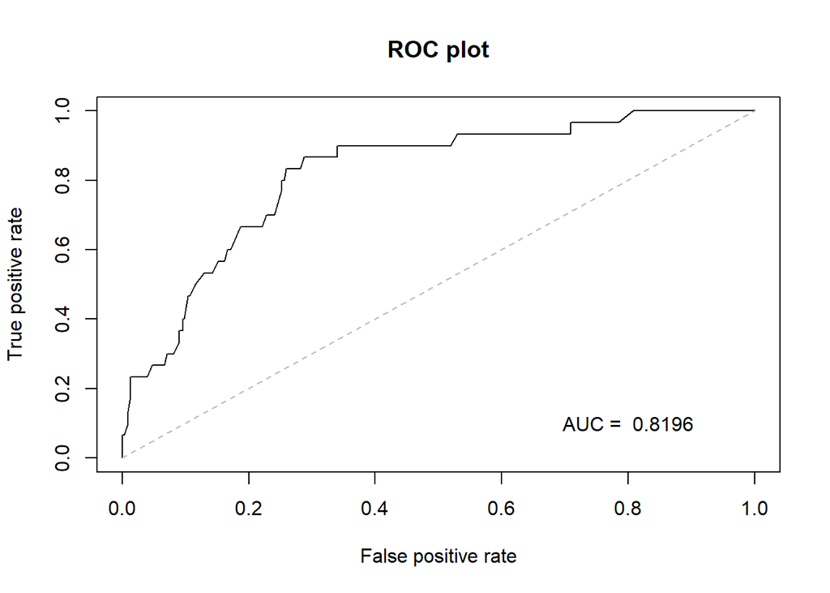

```r
# ROC curve
rocplot <- function(truth, pred, ...){
  predob = prediction(pred, truth)
  perf = performance(predob, "tpr", "fpr")
  plot(perf, colorize=F, ...)
  area = auc(truth, pred)
  area = format(round(area, 4), nsmall = 4)
  text(x = .8, y = .1, labels = paste("AUC = ", area))
  segments(x0 = 0, y0 = 0, x1 = 1, y1 = 1, col = "gray", lty = 2)
}

rocplot(ESP$health_status_1, predict.glm(final1, ESP, type = "response"), title = "ROC plot")
title(main = "ROC plot")
```

### ESP: Good vs Not good

- Outcome: binary health status
- Predictor: numeracy score
- Covariates: education, ethincity, income, race
- Interaction term: education & numeracy score

```r
ESP$health_status_2 <- relevel(ESP$health_status_2, ref = "Good")
full2 <- glm(health_status_2 ~ numeracy + educ + hisp + race +
               income.cat + educ*numeracy, data = ESP,
             family = "binomial")

final2 <- step(full2, direction = "both", trace = 0)
multi_summary2 <- exp(cbind(coef(final2), confint(final2))[-1, ]) %>% as.data.frame()
colnames(multi_summary2)[1] <- "OR"
multi_summary2$sig <- ifelse(summary(final2)$coefficients[-1, 4] < 0.05, "*", "")


# power calculation
powerSim(final2, nsim = 100, progress = FALSE)
```

```
## Power for predictor 'numeracy', (95% confidence interval):
##       100.0% (96.38, 100.0)
##
## Test: z-test
##
## Based on 100 simulations, (0 warnings, 0 errors)
## alpha = 0.05, nrow = 800
##
## Time elapsed: 0 h 0 m 2 s
##
## nb: result might be an observed power calculation
```

```r
kable(multi_summary2) %>%
  kable_styling()
```

OR

2.5 %

97.5 %

sig

numeracy

1.740

1.484

2.12e+00

educSome college or associate’s degree

1.525

0.100

2.37e+01

educBachelor’s degree or higher

0.008

0.000

3.03e-01

educRefused

0.000

NA

3.22e+137

hispNon-hispanic

0.414

0.184

8.73e-01

hispRefused

0.013

0.001

3.55e-01

numeracy:educSome college or associate’s degree

0.987

0.771

1.26e+00

numeracy:educBachelor’s degree or higher

1.500

1.095

2.14e+00

numeracy:educRefused

36.880

0.000

NA

Step-wise multivariate regression model was conducted. The final model has four predictors (educ, hisp, numeracy, and the interaction term between education and numeracy). The AUC is 0.9327 with ROC curve shown below.

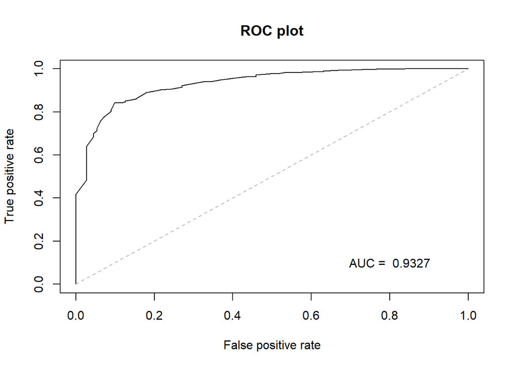

```r
# ROC curve
rocplot(ESP$health_status_2, predict.glm(final2, ESP, type = "response"), title = "ROC plot")
title(main = "ROC plot")
```

### PIAAC (numeracy only): Not Poor vs Poor

- Outcome: binary health status
- predictor: numeracy score
- covariates: income, race, education
- Interaction term: education & numeracy score

```r
PIAAC_clean <- PIAAC %>%
  filter(health_status != "Unknown") %>%
  mutate(health_status_1 = factor(health_status_1),
         health_status_2 = factor(health_status_2))
PIAAC_clean$race[PIAAC_clean$race == "Unknown"] = "Other"
PIAAC_clean$race <- factor(PIAAC_clean$race)
```

```r
full1 <- glm(health_status_1 ~ numeracy + educ + income.cat + race + educ * numeracy, data = PIAAC_clean, family = "binomial")
final1 <- step(full1, direction = "both", trace = 0)
multi_summary1 <- exp(cbind(coef(final1), confint(final1))[-1, ]) %>% as.data.frame()
colnames(multi_summary1)[1] <- "OR"
multi_summary1$sig <- ifelse(summary(final1)$coefficients[-1, 4] < 0.05, "*", "")

# power calculation
powerSim(final1, nsim = 100, progress = FALSE)
```

```
## Power for predictor 'numeracy', (95% confidence interval):
##       100.0% (96.38, 100.0)
##
## Test: z-test
##
## Based on 100 simulations, (0 warnings, 0 errors)
## alpha = 0.05, nrow = 3475
##
## Time elapsed: 0 h 0 m 6 s
##
## nb: result might be an observed power calculation
```

```r
kable(multi_summary1) %>%
  kable_styling()
```

OR

2.5 %

97.5 %

sig

numeracy

0.991

0.988

0.995

income.cat$50k-$100k

0.247

0.132

0.430

income.cat$100k-$150k

0.180

0.054

0.445

income.cat$150k+

0.305

0.104

0.709

income.catNo Data

0.500

0.249

0.911

raceBlack

0.359

0.188

0.640

raceAsian/pacific islander

0.337

0.055

1.105

raceHispanic

0.465

0.246

0.825

raceOther

0.891

0.361

1.884

Step-wise multivariate regression model was conducted on PIAAC data. The final model has three predictors (numeracy, income and race). The AUC is 0.7469 with ROC curve shown below.

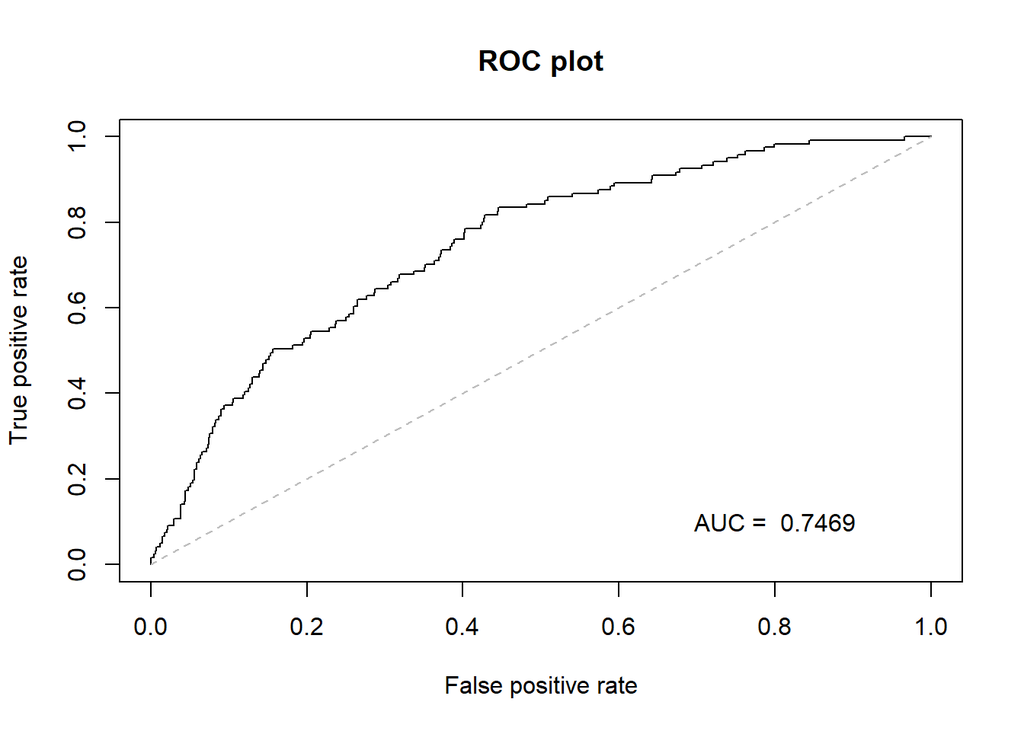

```r
# ROC curve

rocplot(PIAAC_clean$health_status_1, predict.glm(final1, PIAAC_clean, type = "response", na.action = na.omit), title = "ROC plot")
title(main = "ROC plot")
```

### PIAAC (numeracy only): Good vs Not Good

- Outcome: binary health status
- predictor: numeracy score
- covariates: income, race, education
- Interaction term: education & numeracy score

```r
full2 <- glm(health_status_2 ~ numeracy + educ + income.cat + race +
               numeracy * educ, data = PIAAC_clean, family = "binomial")
final2 <- step(full2, direction = "both", trace = 0)
multi_summary2 <- exp(cbind(coef(final2), confint(final2))[-1, ]) %>%
  as.data.frame()
colnames(multi_summary2)[1] <- "OR"
multi_summary2$sig <- ifelse(summary(final2)$coefficients[-1, 4] < 0.05, "*", "")

# power calculation
powerSim(final2, nsim = 100, progress = FALSE)
```

```
## Power for predictor 'numeracy', (95% confidence interval):
##       100.0% (96.38, 100.0)
##
## Test: z-test
##
## Based on 100 simulations, (0 warnings, 0 errors)
## alpha = 0.05, nrow = 3475
##
## Time elapsed: 0 h 0 m 5 s
##
## nb: result might be an observed power calculation
```

```r
kable(multi_summary2) %>%
  kable_styling()
```

OR

2.5 %

97.5 %

sig

numeracy

0.993

0.991

0.995

educSome college or associate’s degree

0.799

0.622

1.020

educBachelor’s degree or higher

0.623

0.478

0.808

educUnknown

1.058

0.048

11.574

income.cat$50k-$100k

0.501

0.397

0.630

income.cat$100k-$150k

0.300

0.198

0.442

income.cat$150k+

0.363

0.231

0.551

income.catNo Data

0.468

0.335

0.644

raceBlack

0.638

0.484

0.834

raceAsian/pacific islander

0.518

0.277

0.898

raceHispanic

0.731

0.550

0.964

raceOther

1.224

0.797

1.844

Step-wise multivariate regression model was conducted. The final model has four predictors (numeracy, education, income and race). The AUC is 0.7098 with ROC curve shown below.

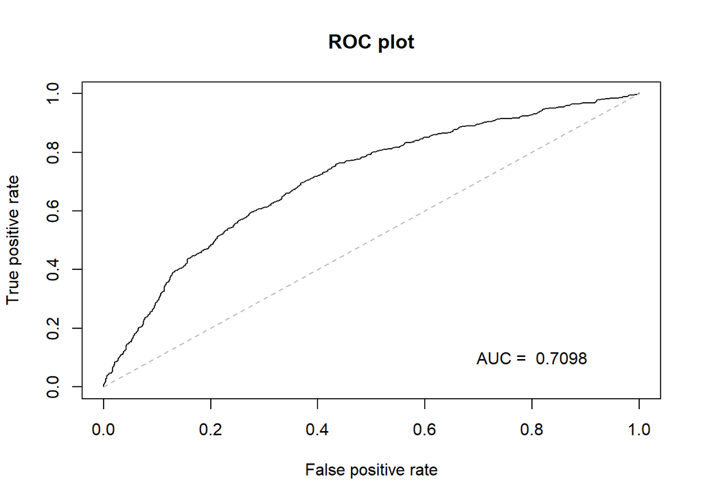

```r
rocplot(PIAAC_clean$health_status_2, predict.glm(final2, PIAAC_clean, type = "response", na.action = na.omit), title = "ROC plot")
title(main = "ROC plot")
```

### PIAAC (additional predictors): Not Poor vs Poor

- Outcome: binary health status
- predictor: numeracy score
- covariates: income, race, education
- Interaction term: education & numeracy score

```r
PIAAC_clean2 <- na.omit(PIAAC_clean)
```

```r
full3 <- glm(health_status_1 ~ numeracy + educ + income.cat + race +
               literacy + problem_solving,
             data = PIAAC_clean[complete.cases(PIAAC_clean), ],
             family = "binomial")
final3 <- step(full3, direction = "both", trace = 0)
multi_summary3 <- exp(cbind(coef(final3), confint(final3))[-1, ]) %>%
  as.data.frame()
colnames(multi_summary3)[1] <- "OR"
multi_summary3$sig <- ifelse(summary(final3)$coefficients[-1, 4] < 0.05, "*", "")

# power calculation
powerSim(final3, nsim = 100, progress = FALSE)
```

```
## Power for predictor 'numeracy', (95% confidence interval):
##       100.0% (96.38, 100.0)
##
## Test: z-test
##
## Based on 100 simulations, (16 warnings, 0 errors)
## alpha = 0.05, nrow = 2869
##
## Time elapsed: 0 h 0 m 9 s
##
## nb: result might be an observed power calculation
```

```r
kable(multi_summary3) %>%
  kable_styling()
```

OR

2.5 %

97.5 %

sig

numeracy

1.022

1.012

1.031

educSome college or associate’s degree

0.354

0.142

0.759

educBachelor’s degree or higher

0.621

0.306

1.208

educUnknown

0.000

NA

Inf

income.cat$50k-$100k

0.244

0.113

0.481

income.cat$100k-$150k

0.113

0.018

0.386

income.cat$150k+

0.264

0.074

0.723

income.catNo Data

0.484

0.180

1.090

raceBlack

0.375

0.125

0.909

raceAsian/pacific islander

0.000

0.000

398.001

raceHispanic

0.773

0.305

1.701

raceOther

1.232

0.360

3.199

problem_solving

0.967

0.957

0.976

Step-wise multivariate regression model was conducted. The final model has five predictors (numeracy, educ, income, race and problem solving). The AUC is 0.8198 with ROC curve shown below.

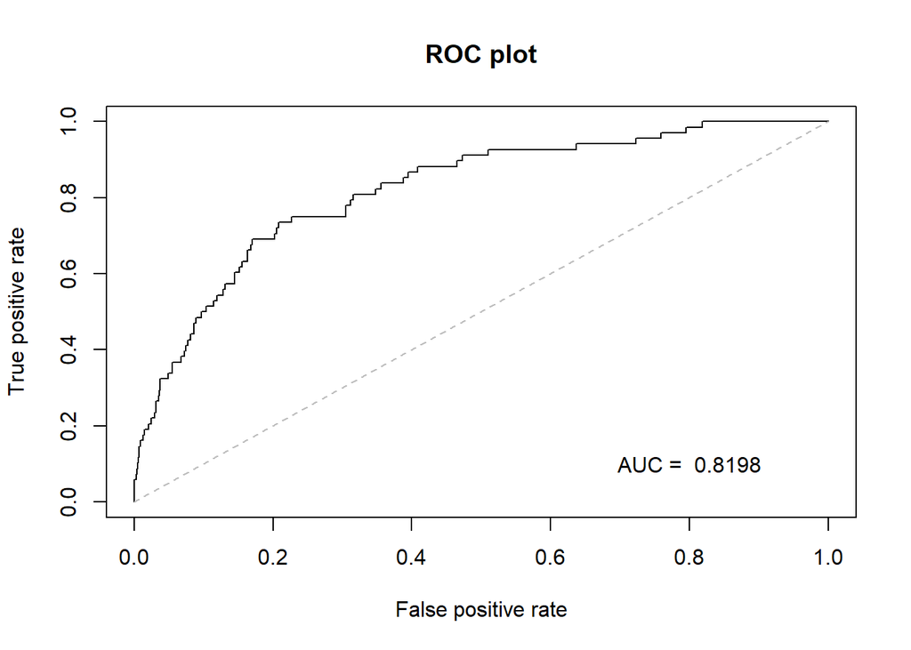

```r
rocplot(PIAAC_clean2$health_status_1, predict.glm(final3, PIAAC_clean2, type = "response", na.action = na.omit), title = "ROC plot")
title(main = "ROC plot")
```

### PIAAC (additional predictors): Good vs Not Good

- Outcome: binary health status
- predictor: numeracy score
- covariates: income, race, education
- Interaction term: education & numeracy score

```r
full4 <- glm(health_status_2 ~ numeracy + educ + income.cat + race +
               literacy + problem_solving,
             data = PIAAC_clean[complete.cases(PIAAC_clean), ],
             family = "binomial")
final4 <- step(full4, direction = "both", trace = 0)
multi_summary4 <- exp(cbind(coef(final4), confint(final4))[-1, ]) %>%
  as.data.frame()
colnames(multi_summary4)[1] <- "OR"
multi_summary4$sig <- ifelse(summary(final4)$coefficients[-1, 4] < 0.05, "*", "")

# power calculation
powerSim(final4, nsim = 100, progress = FALSE)
```

```
## Power for predictor 'numeracy', (95% confidence interval):
##       43.00% (33.14, 53.29)
##
## Test: z-test
##
## Based on 100 simulations, (0 warnings, 0 errors)
## alpha = 0.05, nrow = 2869
##
## Time elapsed: 0 h 0 m 7 s
##
## nb: result might be an observed power calculation
```

```r
kable(multi_summary4) %>%
  kable_styling()
```

OR

2.5 %

97.5 %

sig

numeracy

1.003

1.000

1.01e+00

educSome college or associate’s degree

0.822

0.616

1.09e+00

educBachelor’s degree or higher

0.630

0.467

8.44e-01

educUnknown

0.000

NA

1.34e+24

income.cat$50k-$100k

0.525

0.401

6.83e-01

income.cat$100k-$150k

0.315

0.200

4.79e-01

income.cat$150k+

0.366

0.222

5.79e-01

income.catNo Data

0.436

0.281

6.53e-01

raceBlack

0.761

0.538

1.06e+00

raceAsian/pacific islander

0.566

0.261

1.08e+00

raceHispanic

0.946

0.660

1.34e+00

raceOther

1.466

0.890

2.34e+00

problem_solving

0.990

0.985

9.94e-01

Step-wise multivariate regression model was conducted. The final model has five predictors (numeracy, educ, income, race and problem_solving). The AUC is 0.6907 with ROC curve shown below.

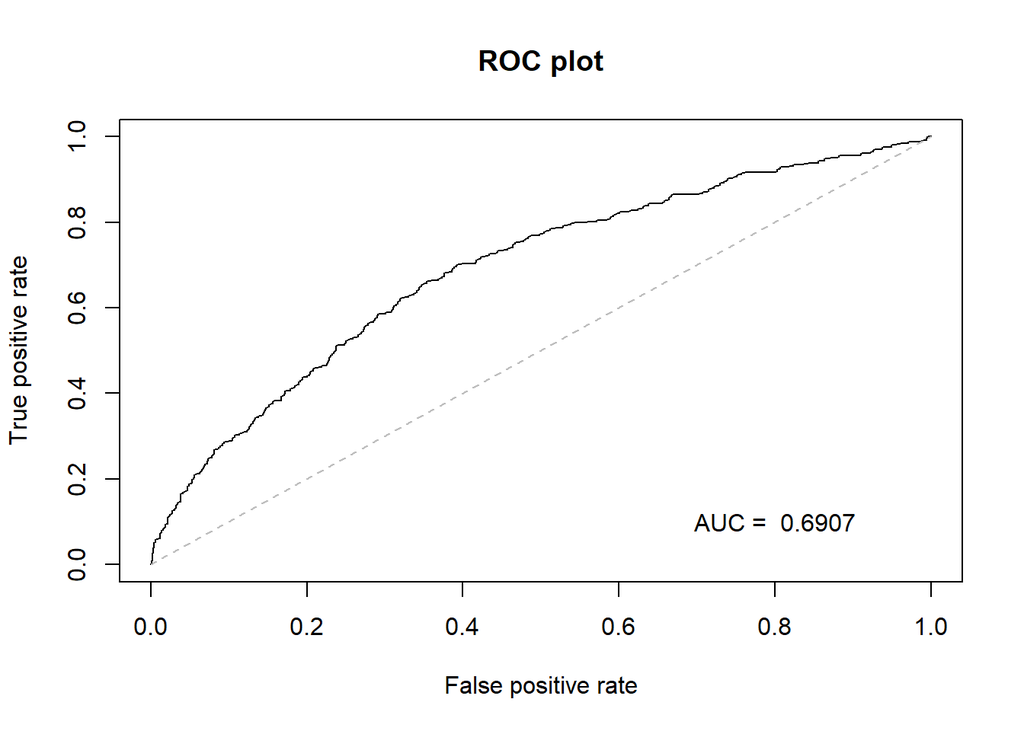

```r
rocplot(PIAAC_clean2$health_status_2, predict.glm(final4, PIAAC_clean2, type = "response", na.action = na.omit), title = "ROC plot")
title(main = "ROC plot")
```

### Refusal Rate

```r
# calculate the number of refuse or -1 (in JAqs) in each column
refuse <- sapply(ESP, function(x) sum(x%in%c("Refused",-1)))
# keep the columns that have refuse
refuse <- refuse[which(refuse>0)]
# append the refuse rate and create a data frame; -2 means remove `age` since it overlaps with age.cat
refuse.df <- rbind(refuse, refuse/8) %>% as.data.frame()
refuse.df <- refuse.df[,-2]
# set col- and rownames
colnames(refuse.df) <- c("Gender", "Age Level", "Education", "Race", "Ethnicity", "JAq1: Fractions", "JAq2: Percentages", "JAq3: Numerical Info")
rownames(refuse.df) <- c("Number", "%")
kable(refuse.df) %>% kable_styling()
```

|  | Gender | Age Level | Education | Race | Ethnicity | JAq1: Fractions | JAq2: Percentages | JAq3: Numerical Info |
| --- | --- | --- | --- | --- | --- | --- | --- | --- |
| Number | 2.00 | 6.00 | 2.00 | 11.00 | 3.000 | 2.00 | 3.000 | 3.000 |
| % | 0.25 | 0.75 | 0.25 | 1.38 | 0.375 | 0.25 | 0.375 | 0.375 |

### Comparing means of numeracy score by health status

Relationship between `numeracy score` and `health status`

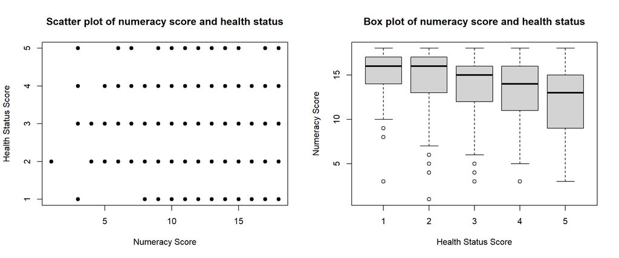

```r
par(mfrow = c(1,2))
plot(x=ESP$numeracy, y=ESP$JAq4, pch=19, xlab = "Numeracy Score", ylab = "Health Status Score", main = "Scatter plot of numeracy score and health status")
boxplot(numeracy~JAq4, data = ESP, xlab = "Health Status Score", ylab = "Numeracy Score", main = "Box plot of numeracy score and health status")
```

```r
# perform one-way ANOVA test
summary(aov(numeracy~health_status, data = ESP))
```

```
##                Df Sum Sq Mean Sq F value  Pr(>F)
## health_status   4    509   127.3    11.8 2.6e-09 ***
## Residuals     795   8577    10.8
## ---
## Signif. codes:  0 '***' 0.001 '**' 0.01 '*' 0.05 '.' 0.1 ' ' 1
```

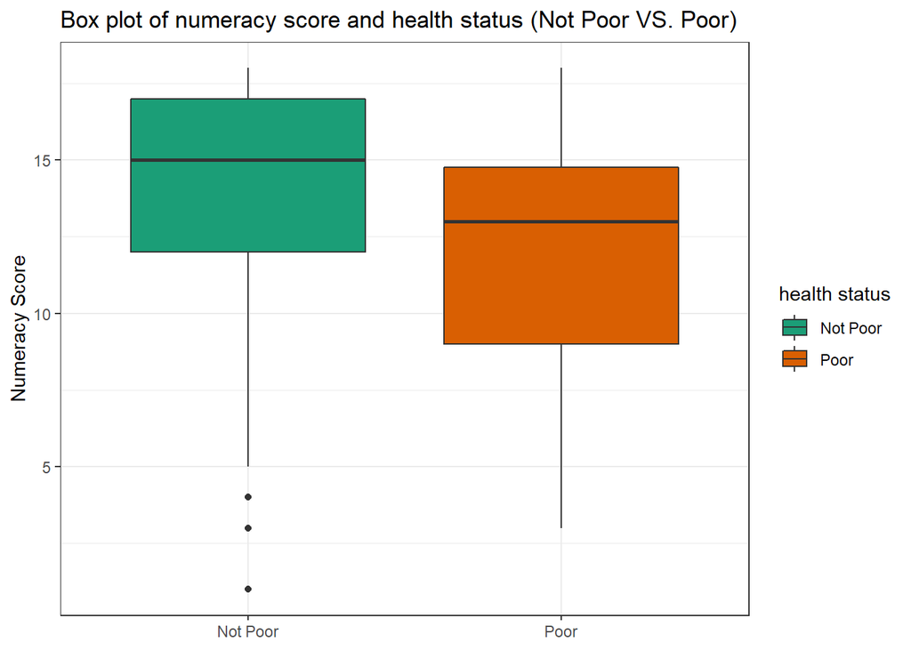

```r
ESP %>% ggplot() +
  geom_boxplot(aes(x=health_status_1, y=numeracy, fill=health_status_1)) +
  labs(title="Box plot of numeracy score and health status (Not Poor VS. Poor) ",y="Numeracy Score", x = NULL, fill="health status") +
  theme_bw() +
  # theme(plot.title = element_text(hjust = 0.5,size = 18)) +
  scale_fill_brewer(palette="Dark2")
```

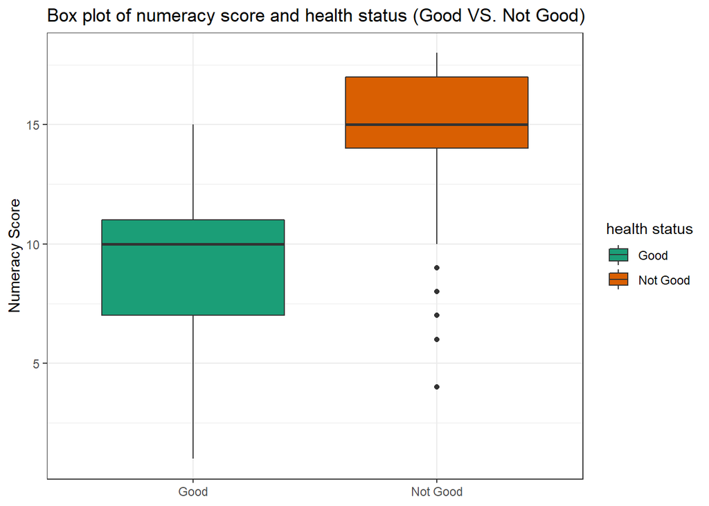

```r
ESP %>% ggplot() +
  geom_boxplot(aes(x=health_status_2, y=numeracy, fill=health_status_2)) +
  labs(title="Box plot of numeracy score and health status (Good VS. Not Good) ",y="Numeracy Score", x = NULL, fill="health status") +
  theme_bw() +
  # theme(plot.title = element_text(hjust = 0.5,size = 18)) +
  scale_fill_brewer(palette="Dark2")
```

### Comparing means of numeracy score by education

Relationship between `numeracy score` and `education`

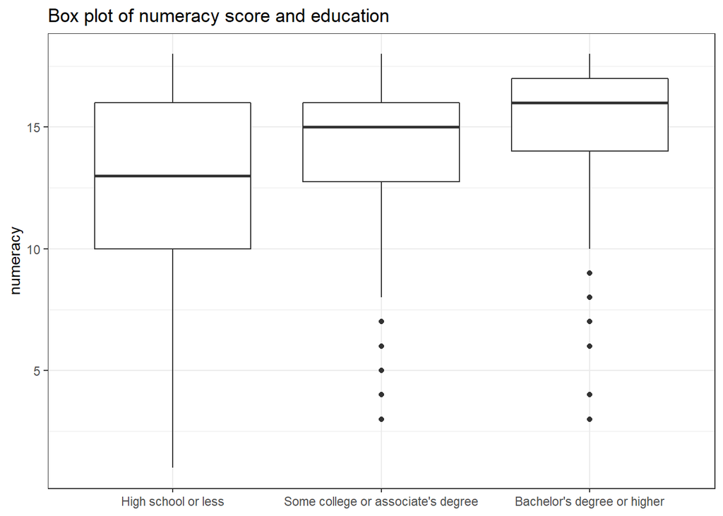

```r
ESP %>%
  filter(educ != "Refused") %>%
  group_by(educ) %>%
  ggplot() +
  geom_boxplot(aes(x=educ, y=numeracy)) +
  theme_bw() +
  labs(x = NULL, title = "Box plot of numeracy score and education")
```

```r
# performe one-way ANOVA test
summary(aov(numeracy~educ, data = ESP))
```

```
##              Df Sum Sq Mean Sq F value Pr(>F)
## educ          3    849   282.9    27.3 <2e-16 ***
## Residuals   796   8238    10.3
## ---
## Signif. codes:  0 '***' 0.001 '**' 0.01 '*' 0.05 '.' 0.1 ' ' 1
```

### ESP vs. NYS (Fisher’s test)

```r
cat.smry <- function(mat, labels = NULL) {
  perc <- paste0(round(prop.table(mat)*100,2),"%")
  n.perc <- paste0(mat,"(",perc,")")
  if(is.null(labels))
    names(n.perc) <- names(mat)
  else
    names(n.perc) <- labels
  return(n.perc)
}
# gather all the cat.smry result for ESP sample
ESP.smry <- c(cat.smry(table(ESP$gender)),
              cat.smry(table(ESP$age.cat)),
              cat.smry(table(ESP$educ)),
              cat.smry(table(ESP$income.cat)),
              cat.smry(table(ESP$race)),
              cat.smry(table(ESP$hisp)))

# join NYS.smry and ESP.smry together (drop levels such as "No data" and "Refused" which are unique for ESP sample by left join NYS)
comp1 <- data.frame(Demographics = rownames(NYS), NYS = NYS$n_perc) %>%
  left_join(data.frame(d = names(ESP.smry), ESP = ESP.smry), by = c("Demographics" = "d"))

# extract counts from ESP.smry
ESP.smry <- comp1$ESP
ESP.n <- c()
for(i in 1:length(ESP.smry)) {
  n.perc <- ESP.smry[i]
  n <- substr(n.perc, 1, unlist(gregexpr("\\(",n.perc))-1)
  ESP.n <- c(ESP.n, n)
}
ESP.n <- as.numeric(ESP.n)
# bind the counts of ESP and NYS preparing for fisher's test
fisher.mat <- rbind(ESP.n, unlist(NYS$counts)) %>% as.matrix()


# add subtitles of demographics
comp1 <- rbind(c("Gender", "", ""), comp1[1:2,],
              c("Age", "", ""), comp1[3:6,],
              c("Education", "", ""), comp1[7:9,],
              c("Income", "", ""), comp1[10:13,],
              c("Race", "", ""), comp1[14:18,],
              c("Ethnicity", "", ""), comp1[19:20,]) %>% as.data.frame()

# append p-values of fisher's test
comp1$pval <- sapply(list(1:2,3:6,7:9,10:13,14:18,19:20),
                     function(x){
                       mat <- fisher.mat[,x]
                       # pval <- fisher_test(mat)$p.value
                       # pval <- fisher.multcomp(mat)$p.signif
                       pval <- fisher.test(mat, simulate.p.value = T)$p.value
                       pval <- ifelse(pval<0.001, "<0.001", round(pval,3))
                       c(pval, rep("",length(x)))
                       }) %>% unlist()

kable(comp1, row.names = F) %>%
  kable_styling(full_width = F) %>%
  row_spec(c(1,4,9,13,18,24), bold = T)
```

| Demographics | NYS | ESP | pval |
| --- | --- | --- | --- |
| Gender |  |  | 0.214 |
| Male | 121301(48.41%) | 403(50.38%) |  |
| Female | 129262(51.59%) | 393(49.12%) |  |
| Age |  |  | 0.121 |
| 18-20 | 11851(4.73%) | 42(5.25%) |  |
| 21-44 | 103469(41.29%) | 298(37.25%) |  |
| 45-64 | 82455(32.91%) | 286(35.75%) |  |
| 65+ | 52788(21.07%) | 168(21%) |  |
| Education |  |  | <0.001 |
| High school or less | 97506(38.92%) | 184(23%) |  |
| Some college or associate’s degree | 69577(27.77%) | 224(28%) |  |
| Bachelor’s degree or higher | 83478(33.32%) | 390(48.75%) |  |
| Income |  |  | <0.001 |
| <$50k | 51303(33.03%) | 253(31.62%) |  |
| $50k-$100k | 64932(41.8%) | 262(32.75%) |  |
| $100k-$150k | 19158(12.33%) | 112(14%) |  |
| $150k+ | 19930(12.83%) | 143(17.88%) |  |
| Race |  |  | <0.001 |
| White | 13559(69.7%) | 543(67.88%) |  |
| Black | 3424(17.6%) | 103(12.88%) |  |
| Asian | 1770(9.1%) | 44(5.5%) |  |
| Natam | 195(1%) | 10(1.25%) |  |
| More than 1 race | 506(2.6%) | 38(4.75%) |  |
| Ethnicity |  |  | 0.667 |
| Hispanic | 41217(16.47%) | 126(15.75%) |  |
| Non-hispanic | 209046(83.53%) | 671(83.88%) |  |

### Info: Weights

**1. Weights are common used in sample survey for adjusting:**

1. Sample design (oversampling of some groups or disproportionate stratification)
2. Nonresponse
3. Bring sample backto being representative of the population ona select set of demographic characteristics

**2. Cnsensus on usage of weight:**

1. General consensus in the literature that weights should be use for descriptive statistics (e.g., Kish & Frankel, 1974)
2. Less consensus on whether weights should be routinely used in multivariate models, such as regression (e.g., Gelman, 2007 and comments; Kott, 2007; Winship & Radbill, 1994)

**Pros**

1. Allow us to claim our results are representative of the population (at least that they have the same distribution on major demographic characteristics as the population)
2. Used to adjust descriptive information on the sample

**Cons**

They introduce a substantial design effect into our data

1. Weights will increase the standard errors of our statistics making our findings less precise and more variable
2. The larger the variability in the weights the larger the design effects
3. This will affect most kinds of statistical analysis
- Descriptive statistics (means, percentages)
- Regression coefficients
- Other multivariate coefficients

**3. Method to test if the weight is needed:**

1. Sensitivity analysis—compare the coefficients of interest from analysis with and without weights. If not significantly different then weights unnecessary.
2. Add the weight and the interaction of the weight with each independent variable to the model. If these do not add significant amount of explained variance to the model, then weights not necessary.
3. When the weights have no effect on the parameter estimates they are called ignorable.

**4. Recommendation**

1. Compare basic substantive model with and without weights and including model-based variables. If same coefficients, unweighted data would be best because of smaller standard errors.
2. Test if a model with the weight and the interactions of the weight with all independent variables included adds significant explained variance. If yes, then use the weighted data or use a model-based approach.

**5. Types of weights**

1. Design Weights: related to sampling fraction(EG: Table 3 in [ESP methodology](https://sri.cornell.edu/sri/polls/files/esp/2019/ESP19%20-%20Introduction%20and%20Methodology%20Report.pdf))
2. Post-Stratification weights: realted to the demographical freatures of population Compute weights separately but sequentially.*(Question)*

### Logistic Regression on Education-Weighted ESP

In the first model with `health status 1` as the outcome, `educational level` and `numeracy` are significant. While in the second model with `health status 2` as the outcome, `ethnicity` and `numeracy` are significant.

```r
ESP.weighted <- ESP %>%
  filter(hisp != "Refused" & educ != "Refused") %>%
  mutate(hisp = factor(hisp), educ = factor(educ), wt = 1)


# This function generate survey weights automatically
surv.wt <- function(x, w, col_pos, col_name){
  # x: dataset of interest
  # w: NYS percentages
  # cpl_pos: column number of the variable to be weighted
  # col_name: name of the variable to be weighted

  x1 <- x %>%
    group_by_at(col_pos) %>%
    summarise(wt = sum(wt)/nrow(x)) %>%
    mutate(wt_new = w/wt) %>%
    select(-wt)

  merge(x, x1, by = col_name) %>%
    mutate(wt = wt * wt_new) %>%
    select(-wt_new)
}
```

```r
# Manully input the NYS education level proportion and hispanic proportion

wt.edu <- c(0.3892, 0.2777, 0.3332)
# wt.hisp <- c(0.1647, 0.8353)


ESP.weighted <- surv.wt(ESP.weighted, wt.edu, 7, "educ")
# ESP.weighted <- surv.wt(ESP.weighted, wt.hisp, c1 = 7, c2 = "hisp")
```

**Not Poor vs Poor**

```r
ESP.design <-svydesign(
        id = ~0,
        data = ESP.weighted ,
        weights = ~ wt
    )

sum1 <- summary(mysvyglm <- svyglm(health_status_1 ~ hisp + educ + numeracy, ESP.design,
                           family=quasibinomial()))
sum1 <- data.frame(sum1$coefficients[-1, c(1, 4)])
colnames(sum1) <- c("Estimate", "P-value")
sum1$sig <- ifelse(sum1$`P-value` <0.05, "\\*", "")


kable(sum1) %>%
  kable_styling(full_width = F)
```

|  | Estimate | P-value | sig |
| --- | --- | --- | --- |
| hispNon-hispanic | 0.769 | 0.201 |  |
| educSome college or associate’s degree | -0.356 | 0.409 |  |
| educBachelor’s degree or higher | -2.143 | 0.002 | * |
| numeracy | -0.122 | 0.010 | * |

**Good vs Not Good**

```r
sum2 <- summary(mysvyglm <- svyglm(health_status_2 ~ hisp + educ + numeracy, ESP.design,
                           family=quasibinomial()))
sum2 <- data.frame(sum2$coefficients[-1, c(1, 4)])
colnames(sum2) <- c("Estimate", "P-value")
sum2$sig <- ifelse(sum2$`P-value` <0.05, "\\*", "")


kable(sum2) %>%
  kable_styling(full_width = F)
```

|  | Estimate | P-value | sig |
| --- | --- | --- | --- |
| hispNon-hispanic | -0.985 | 0.024 | * |
| educSome college or associate’s degree | 0.255 | 0.515 |  |
| educBachelor’s degree or higher | -0.063 | 0.858 |  |
| numeracy | 0.613 | 0.000 | * |

### Logistic regression on RVq2

Visit status (Binary): Not often (#visits <=2) VS. Often (#visits >= 3)

- Predictor: numeracy score
- Covariates: education, ethincity, income, race
- Interaction term: education & numeracy score

```r
ESP$visit_often <- factor(ifelse(ESP$RVq2 >=3, 1, 0))

full1 <- glm(visit_often ~ numeracy + educ + hisp + race + income.cat +
               educ:numeracy, data = ESP,
             family = "binomial")
final1 <- step(full1, direction = "both", trace = 0)
multi_summary1 <- exp(cbind(coef(final1), confint(final1))[-1, ]) %>% as.data.frame()
colnames(multi_summary1)[1] <- "OR"
multi_summary1$sig <- ifelse(summary(final1)$coefficients[-1, 4] < 0.05, "*", "")

# power calculation
powerSim(final1, nsim = 100, progress = FALSE)
```

```
## Power for predictor 'numeracy', (95% confidence interval):
##       38.00% (28.48, 48.25)
##
## Test: z-test
##
## Based on 100 simulations, (0 warnings, 0 errors)
## alpha = 0.05, nrow = 800
##
## Time elapsed: 0 h 0 m 2 s
##
## nb: result might be an observed power calculation
```

```r
kable(multi_summary1) %>%
  kable_styling()
```

97.5 %

sig

numeracy

0.961

0.917

1.007

educSome college or associate’s degree

1.403

0.932

2.116

educBachelor’s degree or higher

1.997

1.348

2.963

educRefused

0.946

0.034

26.014

hispNon-hispanic

1.996

1.241

3.228

hispRefused

2.725

0.217

67.097

raceBlack

0.640

0.414

0.993

raceAsian

0.409

0.217

0.767

raceNatam

0.270

0.055

1.060

raceMore than 1 race

1.427

0.692

3.109

raceOther

0.845

0.419

1.704

raceRefused

0.661

0.168

2.655

Multivariate regression model was conducted with predictors selected by step-wise method. The final model has four predictors (educ, hisp, race and numeracy). The AUC is 0.6348 with ROC curve shown below.

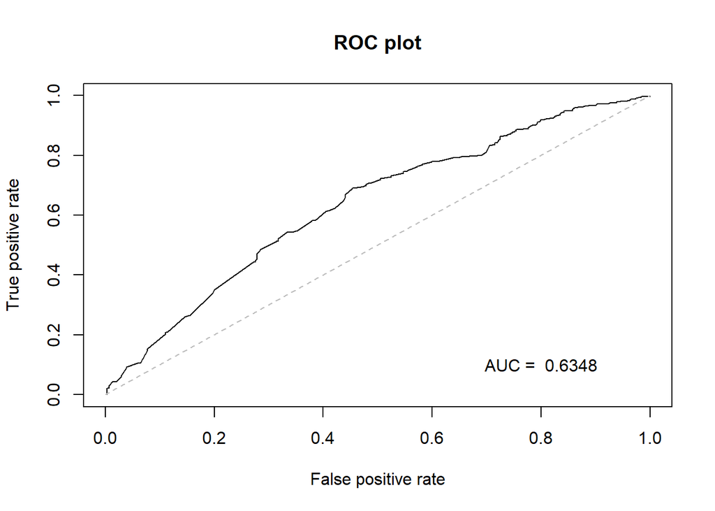

```r
rocplot(ESP$visit_often, predict.glm(final1, ESP, type = "response"), title = "ROC plot")
title(main = "ROC plot")
```

### Poisson regression on RVq2

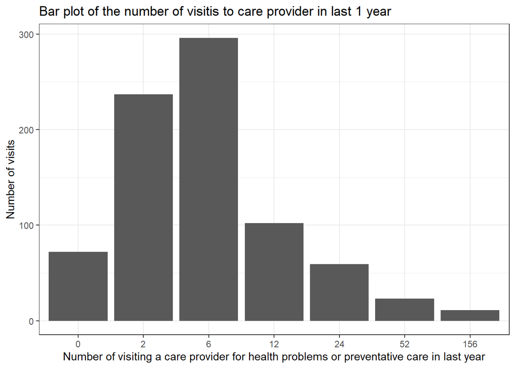

```r
# plot the
library(ggplot2)
ggplot(data=ESP, aes(x=visits_count_1y)) +
   geom_bar()+theme_bw()+
  xlab("Number of visiting a care provider for health problems or preventative care in last year")+ ylab("Number of visits") + ggtitle("Bar plot of the number of visitis to care provider in last 1 year")
```

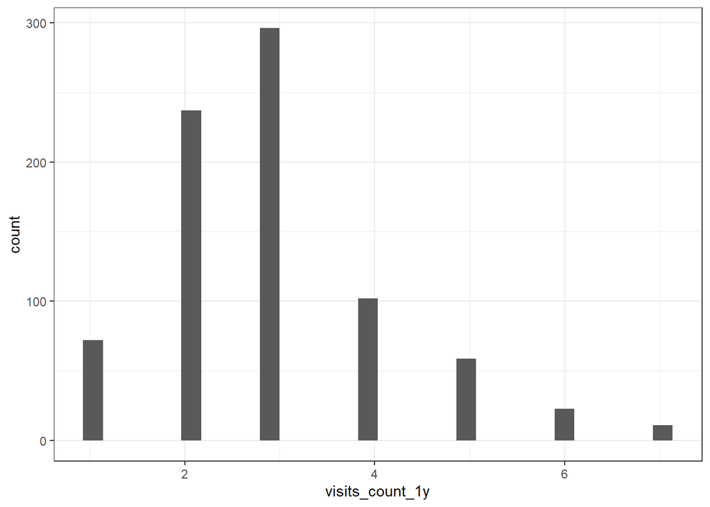

```r
ESP$visits_count_1y <- as.numeric(ESP$visits_count_1y)
ggplot()+ geom_histogram(data=ESP, aes(x=visits_count_1y)) + theme_bw()
```

```r
# colSums(is.na(ESP)) # no NA in ESP
# univariate regression function
str(ESP_full)
```

```
## tibble [800 x 26] (S3: tbl_df/tbl/data.frame)
##  $ ID                : num [1:800] 10021 10030 10035 10052 10055 ...
##  $ nysregion         : Factor w/ 2 levels "Downstate","Upstate": 1 1 1 1 1 1 1 1 1 1 ...
##  $ region_weight     : num [1:800] 1.28 1.28 1.28 1.28 1.28 1.28 1.28 1.28 1.28 1.28 ...
##  $ gender            : Factor w/ 4 levels "Male","Female",..: 1 2 1 1 2 2 2 2 1 2 ...
##  $ age               : num [1:800] 57 72 62 70 41 61 51 91 68 78 ...
##  $ age.cat           : Factor w/ 5 levels "18-20","21-44",..: 3 4 3 4 2 3 3 4 4 4 ...
##  $ educ              : Factor w/ 4 levels "High school or less",..: 3 3 3 1 1 1 3 1 3 1 ...
##  $ income.cat        : Factor w/ 5 levels "<$50k","$50k-$100k",..: 1 1 1 1 2 2 4 1 3 1 ...
##  $ race              : Factor w/ 7 levels "White","Black",..: 1 5 2 2 1 1 2 1 1 6 ...
##  $ hisp              : Factor w/ 3 levels "Hispanic","Non-hispanic",..: 2 2 2 1 1 1 2 1 1 1 ...
##  $ JAq1              : num [1:800] 5 5 6 5 5 1 4 1 4 6 ...
##  $ JAq2              : num [1:800] 6 6 6 3 5 6 2 6 6 1 ...
##  $ JAq3              : num [1:800] 6 6 4 6 6 2 2 6 6 6 ...
##  $ numeracy          : num [1:800] 17 17 16 14 16 9 8 13 16 13 ...
##  $ JAq4              : num [1:800] 4 2 3 5 3 5 3 4 4 4 ...
##  $ health_status     : Factor w/ 5 levels "Excellent","Very Good",..: 4 2 3 5 3 5 3 4 4 4 ...
##  $ health_status_1   : Factor w/ 2 levels "Poor","Not Poor": 2 2 2 1 2 1 2 2 2 2 ...
##  $ health_status_2   : Factor w/ 2 levels "Not Good","Good": 1 1 1 1 1 2 2 1 1 1 ...
##  $ RVq2              : num [1:800] 4 1 2 3 2 3 4 4 2 5 ...
##  $ visits_response_1y: Factor w/ 7 levels "Never","1-2 times",..: 4 1 2 3 2 3 4 4 2 5 ...
##  $ visits_count_1y   : num [1:800] 4 1 2 3 2 3 4 4 2 5 ...
##  $ race.full         : Factor w/ 5 levels "White","Black",..: 1 NA 2 2 1 1 2 1 1 5 ...
##  $ gender.full       : Factor w/ 2 levels "Male","Female": 1 2 1 1 2 2 2 2 1 2 ...
##  $ income.full       : Factor w/ 4 levels "<$50k","$50k-$100k",..: 1 1 1 1 2 2 4 1 3 1 ...
##  $ age.full          : Factor w/ 4 levels "18-20","21-44",..: 3 4 3 4 2 3 3 4 4 4 ...
##  $ educ.full         : Factor w/ 3 levels "High school or less",..: 3 3 3 1 1 1 3 1 3 1 ...
```

```r
ESP_full <- ESP_full[complete.cases(ESP_full),]
ESP_full$visits_count_1y<-as.numeric(ESP_full$visits_count_1y)
univ =function(var){
form =formula(paste0("visits_count_1y ~ ", var))
pois =glm(form, data = ESP_full, family=poisson(link="identity"))
OR =data.frame(round(exp(cbind(OR =coef(pois),confint(pois))), 3))[-1,]
return(OR)
}

#varlist <- colnames(ESP_full)[(colnames(ESP_full)%in% c("numeracy", "health_status_1","health_status_2"))]
varlist <- colnames(ESP_full)[(colnames(ESP_full)%in% c("numeracy", "health_status_1","health_status_2", "age.cat", "gender.full","race.full","income.full","educ.full"))]
df <- do.call(rbind.data.frame,lapply(varlist, univ))
colnames(df)<- c("OR", "2.5% CI","97.5% CI")
kable(df)
```

|  | OR | 2.5% CI | 97.5% CI |
| --- | --- | --- | --- |
| age.cat21-44 | 1.154 | 0.643 | 1.959 |
| age.cat45-64 | 1.142 | 0.636 | 1.940 |
| age.cat65+ | 1.753 | 0.947 | 3.098 |
| numeracy | 0.982 | 0.945 | 1.020 |
| health_status_1Not Poor | 0.410 | 0.180 | 0.847 |
| health_status_2Good | 1.086 | 0.753 | 1.602 |
| race.fullBlack | 0.951 | 0.662 | 1.394 |
| race.fullAsian | 0.561 | 0.355 | 0.935 |
| race.fullNatam | 0.710 | 0.276 | 2.408 |
| race.fullOther | 0.700 | 0.443 | 1.159 |
| gender.fullFemale | 1.362 | 1.060 | 1.749 |
| income.full$50k-$100k | 1.018 | 0.750 | 1.380 |
| income.full$100k-$150k | 1.024 | 0.696 | 1.526 |
| income.full$150k+ | 1.282 | 0.890 | 1.860 |
| educ.fullSome college or associate’s degree | 1.259 | 0.887 | 1.782 |
| educ.fullBachelor’s degree or higher | 1.288 | 0.940 | 1.750 |

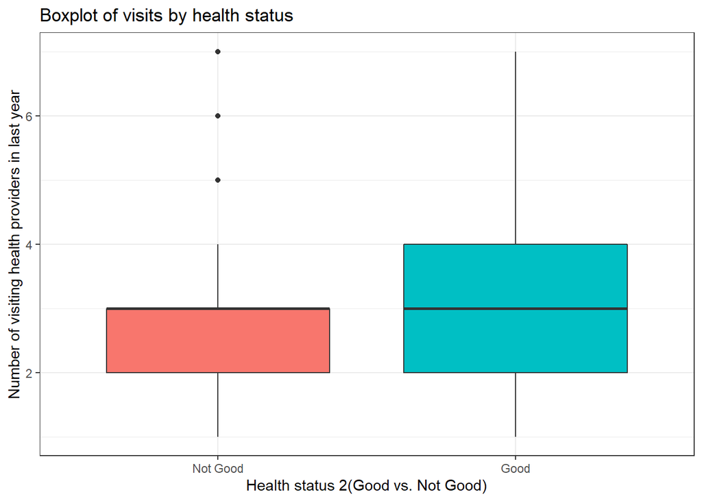

```r
# Boxplot
ggplot()+ geom_boxplot(data = ESP_full,aes(x = health_status_2, y = visits_count_1y, fill = health_status_2))+theme_bw()+labs(x = "Health status 2(Good vs. Not Good)", y = "Number of visiting health providers in last year")+ theme(legend.position = "center")+ggtitle("Boxplot of visits by health status")
```

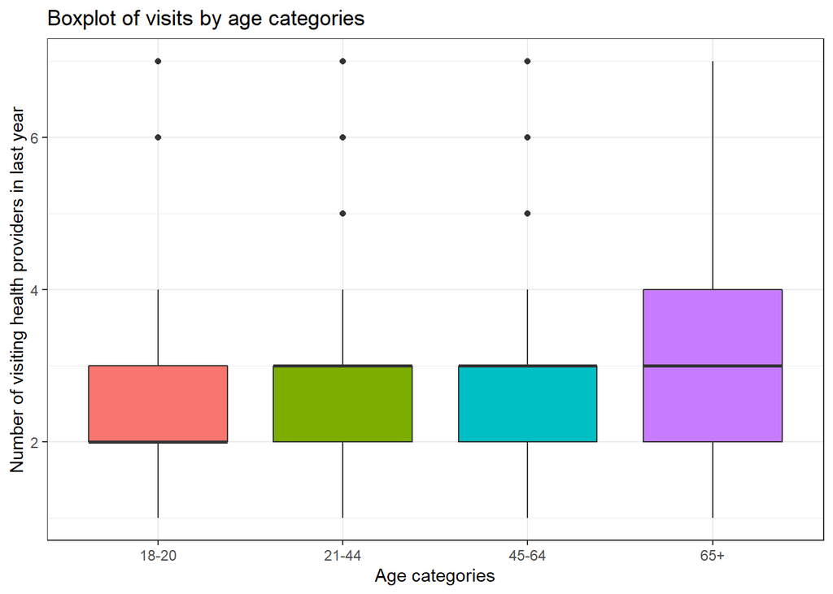

```r
# Boxplot
ggplot()+ geom_boxplot(data = ESP_full,aes(x = age.cat, y = visits_count_1y, fill = age.cat))+theme_bw()+labs(x = "Age categories", y = "Number of visiting health providers in last year")+ theme(legend.position = "center")+ggtitle("Boxplot of visits by age categories")
```

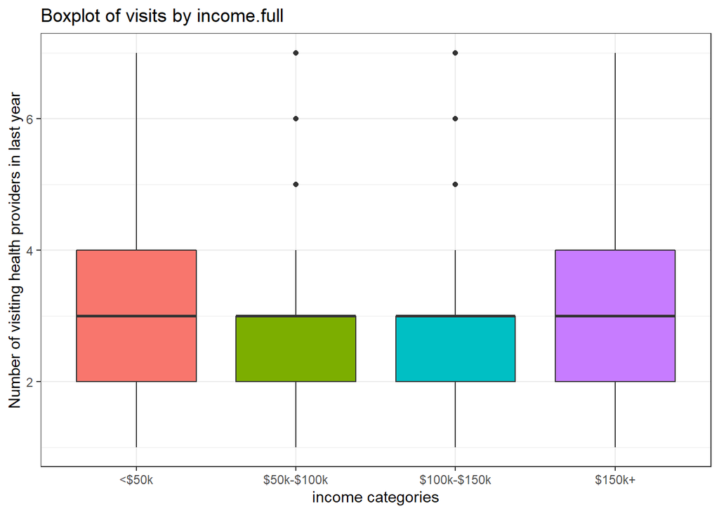

```r
# Boxplot
ggplot()+ geom_boxplot(data = ESP_full,aes(x = income.full, y = visits_count_1y, fill = income.full))+theme_bw()+labs(x = "income categories", y = "Number of visiting health providers in last year")+ theme(legend.position = "center")+ggtitle("Boxplot of visits by income.full")
```

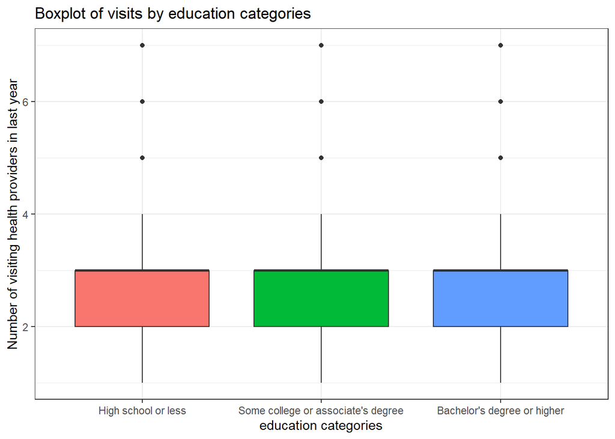

```r
# Boxplot
ggplot()+ geom_boxplot(data = ESP_full,aes(x = educ.full, y = visits_count_1y, fill = educ.full))+theme_bw()+labs(x = "education categories", y = "Number of visiting health providers in last year")+ theme(legend.position = "center")+ggtitle("Boxplot of visits by education categories")
```

#### GLM: Multivariate (good vs. not good)

1. Numeracy does not have significant effect on the number of visits in last year at the significance level of 0.05 controling the education, age, income, and health status 2(good vs. not good).
2. Health status 2(Good vs. Not Good) does not have significant effect on the number of visits in last year at the significance level of 0.05 controling the education, numeracy, income.

```r
# use health_status_2: initial model
pois2 <- glm(visits_count_1y ~numeracy + health_status_2 + educ.full + income.full + age.cat,data = ESP_full, family="poisson")
pander::pander(round(exp(cbind(OR =coef(pois2),confint(pois2))), 3))
```

Waiting for profiling to be done…

|  | OR | 2.5 % | 97.5 % |
| --- | --- | --- | --- |
| **(Intercept)** | 3.12 | 2.26 | 4.276 |
| **numeracy** | 0.985 | 0.968 | 1.003 |
| **health_status_2Good** | 0.964 | 0.82 | 1.13 |
| **educ.fullSome college or associate’s degree** | 1.106 | 0.976 | 1.254 |
| **educ.fullBachelor’s degree or higher** | 1.105 | 0.978 | 1.251 |
| **income.full$50k-$100k** | 1.016 | 0.909 | 1.134 |
| **income.full$100k-$150k** | 1.021 | 0.885 | 1.177 |
| **income.full$150k+** | 1.1 | 0.961 | 1.258 |
| **age.cat21-44** | 1.016 | 0.83 | 1.256 |
| **age.cat45-64** | 1.021 | 0.833 | 1.263 |
| **age.cat65+** | 1.19 | 0.966 | 1.479 |

```r
pander::pander(summary(pois2))
```

|  | Estimate | Std. Error | z value | Pr(>\|z\|) |
| --- | --- | --- | --- | --- |
| **(Intercept)** | 1.138 | 0.1626 | 6.999 | 2.57e-12 |
| **numeracy** | -0.01488 | 0.008872 | -1.677 | 0.09355 |
| **health_status_2Good** | -0.03713 | 0.08171 | -0.4545 | 0.6495 |
| **educ.fullSome college or associate’s degree** | 0.1003 | 0.06397 | 1.569 | 0.1167 |
| **educ.fullBachelor’s degree or higher** | 0.1002 | 0.06272 | 1.598 | 0.1101 |
| **income.full$50k-$100k** | 0.0154 | 0.05646 | 0.2729 | 0.785 |
| **income.full$100k-$150k** | 0.0212 | 0.07277 | 0.2914 | 0.7708 |
| **income.full$150k+** | 0.09544 | 0.06864 | 1.391 | 0.1644 |
| **age.cat21-44** | 0.01568 | 0.1058 | 0.1482 | 0.8822 |
| **age.cat45-64** | 0.0203 | 0.1063 | 0.191 | 0.8485 |
| **age.cat65+** | 0.1739 | 0.1084 | 1.604 | 0.1088 |

(Dispersion parameter for poisson family taken to be 1 )

| Null deviance: | 360.7 on 721 degrees of freedom |
| --- | --- |
| Residual deviance: | 345.1 on 711 degrees of freedom |

#### GLM: Multivariate(health: poor vs. not poor)

Outcome: number of visiting healthy care provider in the last year  
Predictors:  
- Numaracy: (p-value = 0.147)  
- Health status 1: Poor vs. Not Poor(p-value =0.013)  
Covariates:  
- Age categories  
- Income  
- Education

1. Numeracy does not have significant effect on the number of visits in last year at the significance level of 0.05 controling the education, age, income, and health statust(Poor vs. Not Poor).
2. Health status 1(Poor vs. Not Poor) has significant effect on the number of visits in last year at the significance level of 0.05 controling the education, numeracy, income.

```r
# pois2 should be the initial model
# use health_status_1: initial model
pois1 <- glm(visits_count_1y ~numeracy + health_status_1 + educ.full +  income.full + age.cat,data = ESP_full, family="poisson")
pander::pander(round(exp(cbind(OR =coef(pois1),confint(pois1))), 3))
```

Waiting for profiling to be done…

|  | OR | 2.5 % | 97.5 % |
| --- | --- | --- | --- |
| **(Intercept)** | 3.792 | 2.732 | 5.209 |
| **numeracy** | 0.99 | 0.976 | 1.004 |
| **health_status_1Not Poor** | 0.76 | 0.617 | 0.949 |
| **educ.fullSome college or associate’s degree** | 1.114 | 0.983 | 1.264 |
| **educ.fullBachelor’s degree or higher** | 1.124 | 0.993 | 1.273 |
| **income.full$50k-$100k** | 1.021 | 0.914 | 1.14 |
| **income.full$100k-$150k** | 1.035 | 0.896 | 1.193 |
| **income.full$150k+** | 1.111 | 0.97 | 1.271 |
| **age.cat21-44** | 1.004 | 0.82 | 1.241 |
| **age.cat45-64** | 1.002 | 0.817 | 1.241 |
| **age.cat65+** | 1.158 | 0.939 | 1.442 |

```r
pander::pander(summary(pois1))
```

|  | Estimate | Std. Error | z value | Pr(>\|z\|) |
| --- | --- | --- | --- | --- |
| **(Intercept)** | 1.333 | 0.1646 | 8.1 | 5.516e-16 |
| **numeracy** | -0.01037 | 0.00715 | -1.451 | 0.1468 |
| **health_status_1Not Poor** | -0.274 | 0.1098 | -2.496 | 0.01256 |
| **educ.fullSome college or associate’s degree** | 0.1083 | 0.06403 | 1.691 | 0.09077 |
| **educ.fullBachelor’s degree or higher** | 0.1166 | 0.06328 | 1.842 | 0.06547 |
| **income.full$50k-$100k** | 0.02051 | 0.05651 | 0.3629 | 0.7167 |
| **income.full$100k-$150k** | 0.03424 | 0.0731 | 0.4684 | 0.6395 |
| **income.full$150k+** | 0.1049 | 0.06884 | 1.524 | 0.1275 |
| **age.cat21-44** | 0.003677 | 0.1058 | 0.03474 | 0.9723 |
| **age.cat45-64** | 0.001785 | 0.1066 | 0.01675 | 0.9866 |
| **age.cat65+** | 0.1471 | 0.1091 | 1.348 | 0.1776 |

(Dispersion parameter for poisson family taken to be 1 )

| Null deviance: | 360.7 on 721 degrees of freedom |
| --- | --- |
| Residual deviance: | 339.5 on 711 degrees of freedom |

#### Model Selection

```r
pois_all1 <- glm(visits_count_1y ~numeracy + health_status_1 + educ.full + income.full + age.cat,data = ESP_full, family="poisson")
library(car)
# vif(pois_all1)
pois_all1_back <- step(pois_all1, direction = "backward")
```

```
## Start:  AIC=2451
## visits_count_1y ~ numeracy + health_status_1 + educ.full + income.full +
##     age.cat
##
##                   Df Deviance  AIC
## - income.full      3      342 2447
## - educ.full        2      343 2451
## <none>                    339 2451
## - numeracy         1      342 2451
## - age.cat          3      347 2452
## - health_status_1  1      345 2455
##
## Step:  AIC=2447
## visits_count_1y ~ numeracy + health_status_1 + educ.full + age.cat
##
##                   Df Deviance  AIC
## - numeracy         1      343 2447
## <none>                    342 2447
## - age.cat          3      349 2449
## - educ.full        2      348 2449
## - health_status_1  1      347 2451
##
## Step:  AIC=2447
## visits_count_1y ~ health_status_1 + educ.full + age.cat
##
##                   Df Deviance  AIC
## <none>                    343 2447
## - educ.full        2      348 2447
## - age.cat          3      350 2448
## - health_status_1  1      350 2451
```

```r
pander::pander(round(exp(cbind(OR =coef(pois_all1_back),confint(pois_all1_back))), 3))
```

Waiting for profiling to be done…

|  | OR | 2.5 % | 97.5 % |
| --- | --- | --- | --- |
| **(Intercept)** | 3.406 | 2.539 | 4.513 |
| **health_status_1Not Poor** | 0.753 | 0.613 | 0.937 |
| **educ.fullSome college or associate’s degree** | 1.108 | 0.98 | 1.254 |
| **educ.fullBachelor’s degree or higher** | 1.13 | 1.008 | 1.268 |
| **age.cat21-44** | 1.008 | 0.823 | 1.246 |
| **age.cat45-64** | 1.002 | 0.817 | 1.241 |
| **age.cat65+** | 1.151 | 0.934 | 1.432 |

```r
pander::pander(summary(pois_all1_back))
```

|  | Estimate | Std. Error | z value | Pr(>\|z\|) |
| --- | --- | --- | --- | --- |
| **(Intercept)** | 1.225 | 0.1467 | 8.356 | 6.49e-17 |
| **health_status_1Not Poor** | -0.2836 | 0.1081 | -2.624 | 0.008684 |
| **educ.fullSome college or associate’s degree** | 0.1025 | 0.06294 | 1.628 | 0.1035 |
| **educ.fullBachelor’s degree or higher** | 0.1219 | 0.05832 | 2.09 | 0.03663 |
| **age.cat21-44** | 0.007766 | 0.1058 | 0.07343 | 0.9415 |
| **age.cat45-64** | 0.00215 | 0.1065 | 0.02018 | 0.9839 |
| **age.cat65+** | 0.141 | 0.109 | 1.293 | 0.196 |

(Dispersion parameter for poisson family taken to be 1 )

| Null deviance: | 360.7 on 721 degrees of freedom |
| --- | --- |
| Residual deviance: | 343.5 on 715 degrees of freedom |

```r
# other selection to ensure the one we provide is the most simplified
# use health_status_1: full model
pois_all1 <- glm(visits_count_1y ~numeracy + health_status_1 + educ.full + income.full + age.cat,data = ESP_full, family="poisson")
library(car)
vif(pois_all1)
pois_all1_step <- step(pois_all1, direction = "both")

pois_all1_back <- step(pois_all1, direction = "backward")
pois_all1_for <- step(pois_all1, direction = "forward")
# use health_status_2: full model
pois_all2 <- glm(visits_count_1y ~numeracy + health_status_2 + educ.full + income.full + age.cat + race.full + gender.full,data = ESP_full, family="poisson")
vif(pois_all2)
pois_all2_step <- step(pois_all2, direction = "both")
pois_all2_back <- step(pois_all2, direction = "backward")
pois_all2_for <- step(pois_all2, direction = "forward")
```